# NI05 Annotate Non Tumor Epitheial Clusters

```r
library(Seurat)
library(ggplot2)
library(tidyverse)
require(corrplot)
library(clustree)
```

```r
load(file=paste(dir,"Data_input/objects/objects/NI04_tumor_seurat_object.RData", sep=""))
```

[output not shown]

Look for clincal mutation found in normal classified cells

```r
cell_mutation_tab <- read.csv(file = paste(dir, "Data_input/objects/validationTable_cells.4.19.19.csv", sep = ""))
rownames(cell_mutation_tab) <- cell_mutation_tab$cell
cell_mutation_tab$tumorCell_bool <- NULL

# Subset cell_mutation_tab to only normal cells
normal_cells <- filter(tiss_nonimmune_epi@meta.data, inferCNV_annotation == "nontumor")
normal_cells <- normal_cells$cell_id
length(normal_cells)
normal_cell_mutation_tab <- cell_mutation_tab[normal_cells, ]

sub_normal_cell_mutation_tab <- filter(normal_cell_mutation_tab, clinical_mutation_found_bool == 1)
sub_normal_cell_mutation_tab
# only one cell confirmed with clincial mutation (G22_B003776)
```

Subset the Normal Epithelial cells, recluster and annotate

```r
table(tiss_nonimmune_epi@meta.data$inferCNV_annotation)
```

```
nontumor    tumor
    1827     3754
```

Fix biop. site metadata

```r
tiss_subset_normalepi@meta.data$biopsy_site <- gsub(pattern = "lung", replacement = "Lung", x = tiss_subset_normalepi@meta.data$biopsy_site)
table(tiss_subset_normalepi@meta.data$biopsy_site)
```

Normalize and scale the data

```r
tiss_subset_normalepi <- NormalizeData(object = tiss_subset_normalepi)
```

Find variable genes

```r
tiss_subset_normalepi <- FindVariableFeatures(object = tiss_subset_normalepi)
```

Scale data

```r
tiss_subset_normalepi <- ScaleData(object = tiss_subset_normalepi, features = rownames(tiss_subset_normalepi))
```

Perform PCA

```r
tiss_subset_normalepi <- RunPCA(object = tiss_subset_normalepi)
```

Visualize top genes in principal components

```r
DimHeatmap(object = tiss_subset_normalepi, dims = 1:10, cells = 100, balanced = TRUE)
```

Perform correlation of PCs and metadata fields

```r
pca.obj <- tiss_subset_normalepi@reductions$pca
pc.coords <- pca.obj@cell.embeddings
df1 <- tiss_subset_normalepi@meta.data[,c("nFeature_RNA","nCount_RNA","percent.ribo")]
df2 <- pc.coords[,c(1:10)]
cordf12 <- cor(df1,df2)
# Make a correlation plot
corrplot(cordf12, method = "number", main="Correlation of PCs and metadata")
```

Also visaulize PC variance

```r
ElbowPlot(object = tiss_subset_normalepi, ndims = 30)
```

Choose the number of principal components to use.

```r
n.pcs = 20
```

Find Neighbors

```r
tiss_subset_normalepi <- FindNeighbors(object = tiss_subset_normalepi, dims = 1:n.pcs, verbose = T, k.param = 20)
```

Check clustering stability at given resolution (Clustree)

```r
# Set different resolutions
res.used <- seq(0.1,1,by=0.2)
# Loop over and perform clustering of different resolutions
for(i in res.used){
tiss_subset_normalepi <- FindClusters(object = tiss_subset_normalepi, verbose = T, resolution = res.used)}
# Make Plot
clus.tree.out <- clustree(tiss_subset_normalepi, layout="sugiyama") +
    theme(legend.position = "bottom") +
  scale_color_brewer(palette = "Set1") +
    scale_edge_color_continuous(low = "grey80", high = "red")
ggsave(clus.tree.out, filename = paste(dir, "plot_out/NI05/clustree_out.pdf", sep = ""))
clus.tree.out
```

Set resolution and perform clustering

```r
res.used <- 0.5
tiss_subset_normalepi <- FindClusters(object = tiss_subset_normalepi, verbose = T, resolution = res.used)
```

Perform tSNE

```r
tiss_subset_normalepi <- RunTSNE(object = tiss_subset_normalepi, dims.use = 1:n.pcs, seed.use = 10)
```

Visualize TSNE colroed by cluster

```r
pdf(file = paste(dir, "plot_out/NI05/nontumor_epi_tsne.pdf", sep = ""))
DimPlot(object = tiss_subset_normalepi, reduction = 'tsne')
dev.off()
```

Cluster Occ by patient

```r
# Calculate mixing score for each cluster
tab.1 <- table(tiss_subset_normalepi@meta.data$patient_id, tiss_subset_normalepi@meta.data$seurat_clusters)
occ_score <- apply(tab.1, 2, max)/colSums(tab.1)
# Plot mixing score
pdf(file = paste(dir, "plot_out/NI05/clusocc_bargraph.pdf", sep = ""))
par(las=3);barplot(sort(occ_score), xlab="Cluster", ylab="Patient max Ncells/Total cells", ylim=c(0,1));abline(h=0.7, col="red")
dev.off()
```

Compare cluster occ of normal epi to tumor

```r
# noraml
tab.1 <- table(tiss_subset_normalepi@meta.data$patient_id, tiss_subset_normalepi@meta.data$seurat_clusters)
occ_score <- apply(tab.1, 2, max)/colSums(tab.1)
normal_occ <- as.data.frame(occ_score)
normal_occ$group <- "normal"
colnames(normal_occ) <- c("score", "group")

# tumor
tab.2 <- table(tiss_subset_tumor2@meta.data$patient_id, tiss_subset_tumor2@meta.data$seurat_clusters)
occ_score2 <- apply(tab.2, 2, max)/colSums(tab.2)
tumor_occ <- as.data.frame(occ_score2)
tumor_occ$group <- "tumor"
colnames(tumor_occ) <- c("score", "group")

occ_combo <- rbind(normal_occ, tumor_occ)

occ_changes <- ggplot(occ_combo,aes(x=score)) +
    # geom_histogram(data=subset(occ_combo, group == 'normal'),fill = "blue", alpha = 0.2, bins = 5) +
    # geom_histogram(data=subset(occ_combo, group == 'tumor'),fill = "red", alpha = 0.2, bins = 5) +
    geom_density(data=subset(occ_combo, group == 'normal'), size = 1.5, colour = "blue") +
    geom_density(data=subset(occ_combo, group == 'tumor'), size = 1.5, colour = "red")

ggsave(occ_changes, filename = paste(dir, "plot_out/NI05/NI05_occ_changes_tumor_nontumor.pdf", sep = ""), width = 10, height = 10)
```

Find markers for each cluster

```r
unique(tiss_subset_normalepi@active.ident)
tiss.markers.epi <- FindAllMarkers(object = tiss_subset_normalepi, only.pos = TRUE, min.pct = 0.25, thresh.use = 0.25)
```

Write differential gene table

```r
write.csv(tiss.markers.epi, file = paste(dir, "data_out/NI05/NI05_DE_epithelial.csv", sep = ""))
```

Display the top markers you computed above.

```r
tiss.markers.epi %>% group_by(cluster) %>% top_n(20, avg_logFC)
#cluster 5 mesenchyme?
```

Create dotplots of the top markers displayed above

```r
markers.small  <- tiss.markers.epi %>% group_by(cluster) %>% top_n(5, avg_logFC)
genes_to_check <- markers.small$gene
DotPlot(object = tiss_subset_normalepi, features = genes_to_check) + coord_flip()
```

ID cell types using cell markers

```r
# Cell markers
s.muscle <- c('CNN1','SUSD5','ACTC1','ASB2','KCNA5','LDB3','MYOCD','ELN','ACTG2','ACTA2')
neuro.e <- c('RESP18','NOV','SCG5','NNAT','CALCA','PTPRN','SLC35D3','ASCL1','CHGA')
glial <- c('KCNA1','CDH19','SOX10','GFRA3','PLP1','GPR37L1','ART3','RASGEF1C','KCNA6','GFAP')
club <- c('GABRP','CCKAR','HP','KCNK2','UPK3A','CLDN10','PON1','SCGB1A1','BPIFB1','MUC5B')
ciliated <- c('CDHR3','FOXJ1','RGS22','MAPK15','SPEF2','CCDC153')
at2 <- c('NAPSA','CHIA','SFTPC','SFTPB','MUC1','SFTPA1','SFTPA2')
at1 <- c('IGFBP2','COL4A3','PDPN','AGER','CAV1','CDKN2B','RTKN2')
ionocytes <- c('ATP6V1C2','ATP6V0D2','CFTR','FOXI1','ASCL3')
basal <- c('KRT17','KRT5','SYT8','FHL2','MMP1')
heptaocyte <- c('ALB')
all_epi_markers <- c(s.muscle, neuro.e, glial, club, ciliated, at2, at1, basal, heptaocyte)
pdf(file = paste(dir,"plot_out/NI05/dotplotepimarkers.pdf", sep = ""))
DotPlot(object = tiss_subset_normalepi, features = all_epi_markers) + coord_flip()
dev.off()

DotPlot(object = tiss_subset_normalepi, features = s.muscle) + coord_flip() # none
DotPlot(object = tiss_subset_normalepi, features = neuro.e) + coord_flip() # 10
DotPlot(object = tiss_subset_normalepi, features = glial) + coord_flip() # none
DotPlot(object = tiss_subset_normalepi, features = club) + coord_flip() # 4?
DotPlot(object = tiss_subset_normalepi, features = ciliated) + coord_flip() #9
DotPlot(object = tiss_subset_normalepi, features = at2) + coord_flip() # 0, 1, 3, 13
DotPlot(object = tiss_subset_normalepi, features = at1) + coord_flip() #2
DotPlot(object = tiss_subset_normalepi, features = ionocytes) + coord_flip() #12
DotPlot(object = tiss_subset_normalepi, features = basal) + coord_flip() #14
DotPlot(object = tiss_subset_normalepi, features = heptaocyte) + coord_flip() #7
```

Create table of how many cells belong to each cluster assignment

```r
table(tiss_subset_normalepi@meta.data$seurat_clusters)
```

Set Metadata Column for Cluster IDs

```r
tiss_subset_normalepi@meta.data$normalepi_seurat_cluster <- tiss_subset_normalepi@meta.data$seurat_clusters
```

Annotate the normal epi cells

```r
table(is.na(tiss_subset_normalepi@meta.data$norm_epi_annotation))
```

```
FALSE
 1827
```

Plot tSNE with annoations

```r
pdf(file = paste(dir, "plot_out/NI05/NI05_norm_epi_annotated_tsne.csv", sep = ""))
TSNEPlot(object = tiss_subset_normalepi, group.by='norm_epi_annotation')
dev.off()
```

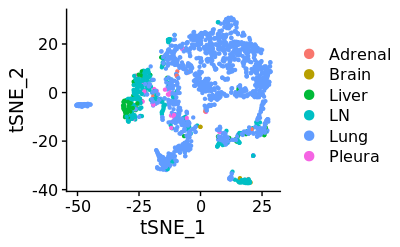

```r
TSNEPlot(object = tiss_subset_normalepi, group.by='biopsy_site')
```

```r
pdf(file = paste(dir, "plot_out/NI05/NI05_normepi_tsne_patientid.pdf", sep = ""))
DimPlot(object = tiss_subset_normalepi, reduction = 'tsne', group.by = "patient_id")
dev.off()
```

Save object

```r
save(tiss_subset_normalepi, file = paste(dir, "Data_input/objects/NI05_normalepi_seurat_object_annotated.RData", sep = ""))
# load(file = paste(dir, "Data_input/objects/NI03_epithelial_annotated_tumor.RData", sep = ""))
```

save normal epi annotations to all epi seurat object

```r
table(tiss_nonimmune_epi@meta.data$epi_anno_final)
```

```
alveolar type 1 cell alveolar type 2 cell
                 216                  926
          basal cell        ciliated cell
                  19                   43
           club cell           hepatocyte
                 155                   96
            ionocyte         neuro.e cell
                  22                   40
               tumor      unknown stroma1
                3754                  107
     unknown stroma2      unknown stroma3
                 104                   46
     unknown stroma4      unknown stroma5
                  39                   14
```

[figure not shown]

[figure not shown]